# Resolución Actividad 2 Máster Bioinformática UNIR (2025)

Melissa Ndombasi Bokuy

2025-12-14

**Introducción**

**Presentación de resultados**

En las tabla descriptivas, se reflejarán las medias y desviaciones estándar en caso de ser datos paramétricos; y las medianas y rangos intercuartílicos si son datos no paramétricos. Así como el valor P del contraste de hipótesis correspondiente a cada una de las variables para determinar si existen diferencias significativas entre los pacientes sometidos o no a tratamiento y así como en función de su extensión tumoral.

##### 1. Instalar y cargar librerías

Comenzamos instalando y cargando los paquetes necesarios para el uso de las librerías de interés para el análisis. Sólo se requiere la instalación si no han sido previamente instalados.

```r
# install.packages(c("ggplot2", "dplyr", "tidyr", "readr", "scales", "patchwork","gtsummary", "nortest","gt"))

library(ggplot2) # Gráficos principales
library(dplyr) # Manipulación de datos
library(tidyr) # Transformación de datos
library(readr) # Importar datos
library(scales) # Funciones extra para escalas
library(patchwork) # Combinar gráficos fácilmente
library(pheatmap) # Heatmaps
library(gtsummary) # tablas descriptivas
library(nortest) # prueba de normalidad
library(gt) # Formatear tablas a formato gt
```

##### 2. Importar datos

Establecemos el directorio de trabajo, importamos el archivo de datos y realizamos una primera observación del fichero para entender su contenido y estructura.

```r
getwd
setwd("~/Documents/Máster bioinformática 2025-2027/Estadistica y R para Ciencias de la Salud")
datos <- read.csv("Actividades/Actividad 2/mubio02_act2(1)/MUBioinfo_dataset_genes_oct2025 (1).csv")
View(datos)
str(datos)
summary(datos)
```

##### 3. Exploración de los datos

En primer lugar, elaboramos una tabla descriptiva de las variables del dataset para tener una idea preliminar de su comportamiento. Para ello, extraemos los descriptivos básicos en función del tipo de variable:

```r
descriptivo_var <- function(x) {
  x_no_na <- x[!is.na(x)]

  # Variables categóricas
  if (is.factor(x) || is.character(x)) {
    tab <- table(x_no_na)
    return(paste(names(tab), tab, sep = ": ", collapse = "; "))
  }

  # Variables  continuas
  if (is.numeric(x)) {
    p_norm <- ad.test(x_no_na)$p.value

    if (p_norm >= 0.05) {
      return(paste0(
        "media = ", round(mean(x_no_na), 2),
        ", var = ", round(var(x_no_na), 2)
      ))
    } else {
      return(paste0(
        "mediana = ", round(median(x_no_na), 2),
        " (", round(quantile(x_no_na, 0.25), 2),
        "-", round(quantile(x_no_na, 0.75), 2), ")"
      ))
    }
  }

  return(NA)
}

# Aplicación de la función al dataset

tabla_descriptivos <- data.frame(
  Variable = names(datos),
  Resumen = sapply(datos, descriptivo_var),
  row.names = NULL
)

tabla_descriptivos # Visualización de los resultados en la consola R
```

```r
# Formatear tabla con formato gt

tabla_gt <- tabla_descriptivos %>%
  gt() %>%
  tab_header(
    title = "Tabla descriptiva de las variables",
    subtitle = "Variables categóricas y cuantitativas"
  ) %>%
  cols_label(
    Variable = "Variable",
    Resumen  = "Descriptivo"
  ) %>%
  tab_options(
    table.font.size = px(13),
    heading.title.font.size = px(15),
    heading.subtitle.font.size = px(12)
  ) %>%
  opt_all_caps() %>%
  opt_table_outline()

tabla_gt
```

Tabla descriptiva de las variables

Variables categóricas y cuantitativas

| Variable | Descriptivo |
| --- | --- |
| id | media = 33, var = 357.5 |
| tratamiento | farmaco: 32; placebo: 33 |
| extension | localizado: 32; metastasico: 33 |
| edad | media = 65.46, var = 140.29 |
| sexo | mujer: 40; varon: 25 |
| exfumador | no: 34; si: 31 |
| hta | no: 39; si: 26 |
| dm | no: 53; si: 12 |
| alergia | no: 58; si: 7 |
| cardiopatia | no: 56; si: 9 |
| ete | no: 58; si: 7 |
| neumopatia | no: 51; si: 14 |
| hepatopatia | no: 62; si: 3 |
| colelitiasis | no: 59; si: 6 |
| utolitiasis | no: 63; si: 2 |
| itu | no: 63; si: 2 |
| renal | no: 63; si: 2 |
| neuropatia | no: 53; si: 12 |
| corticoides | antiemesis: 27; no: 30; si: 8 |
| tos | no: 57; si: 8 |
| disnea | no: 57; si: 8 |
| expect | no: 55; si: 10 |
| secrecion | no: 50; si: 15 |
| dolor_garg | no: 62; si: 3 |
| escalofrios | no: 61; si: 4 |
| fiebre | no: 64; si: 1 |
| diarrea | no: 55; si: 10 |
| nauseas | no: 57; si: 8 |
| vomitos | no: 62; si: 3 |
| cefalea | no: 50; si: 15 |

[output cut: 56 more lines]

**PARTE 1** - Comprobar la normalidad de los genes y realizar una interpretación de los resultados obtenidos.

A/ Histogramas de la expresión de los genes, para obtener una primera idea de su distribución.

```r
df_AQ <- datos %>% select(contains("AQ"))
head(df_AQ)

AQ_names <- names(df_AQ) # nombre variables
histograms <- list() # lista vacía

for (i in AQ_names) {
  h <- ggplot(df_AQ, aes_string(i)) +
    geom_histogram(
      bins = 30, # número de barras
      color = "white", # color del borde de las barras
      fill = "skyblue", alpha = 0.8 # color de relleno de las barras
    ) +
    labs(
      title = i,
      x = paste0("Valores de", i),
      y = "Frecuencia"
    ) +
    theme_minimal()

  # Guardar en la lista con nombre h_[var]
  histograms[[paste0("h_", i)]] <- h
}
```

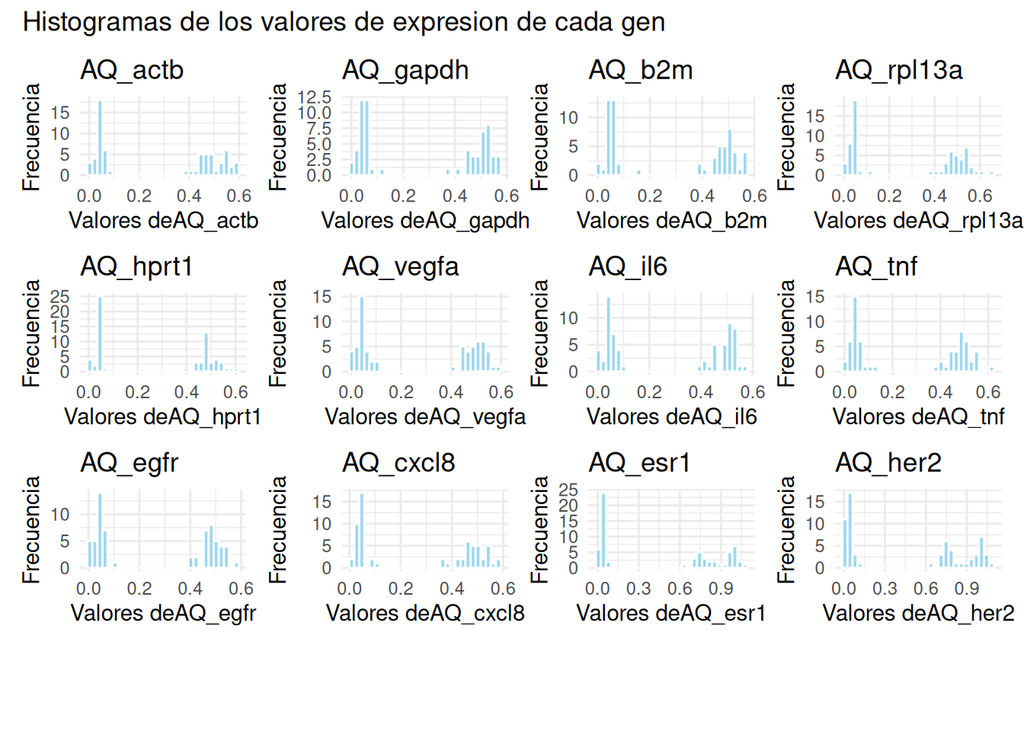

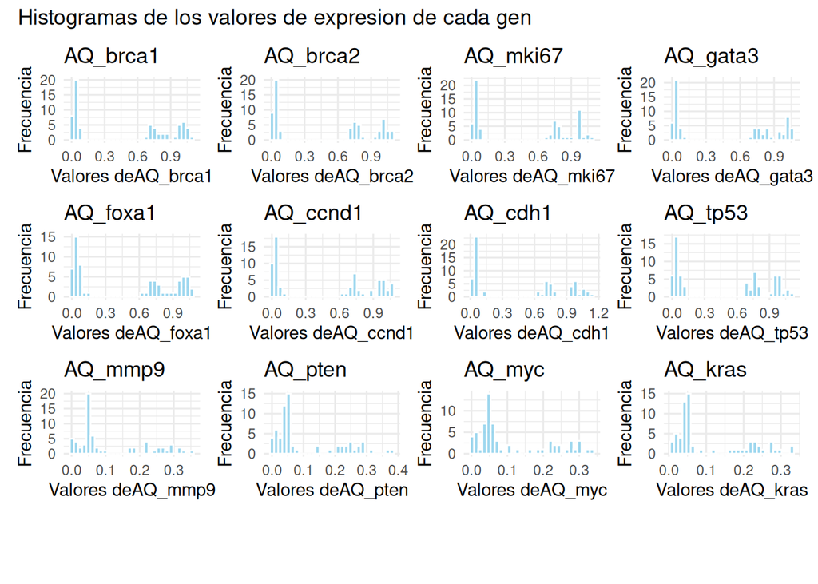

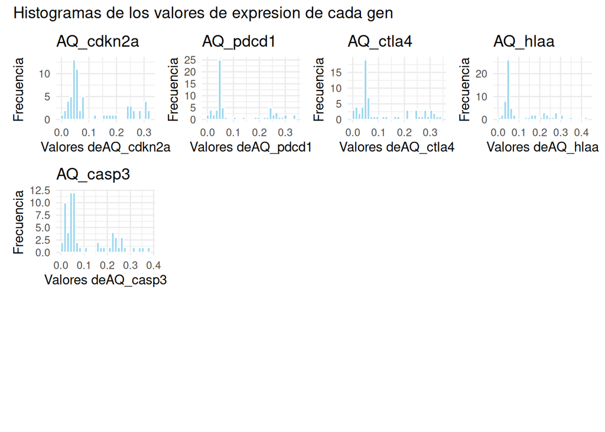

```r
# Gráfico combinado de los histogramas variables de 1-12
combined_histograms_1 <- (histograms[[1]] + histograms[[2]] + histograms[[3]] + histograms[[4]] + histograms[[5]] + histograms[[6]] + histograms[[7]] + histograms[[8]] + histograms[[9]] + histograms[[10]] + histograms[[11]] + histograms[[12]]) +
  plot_layout(ncol = 4, nrow = 4) +
  plot_annotation(
    title = "Histogramas de los valores de expresion de cada gen",
    theme = theme_minimal()
  )

# Gráfico combinado de los histogramas variables de 13-25
combined_histograms_2 <- (histograms[[13]] + histograms[[14]] + histograms[[15]] + histograms[[16]] + histograms[[17]] + histograms[[18]] + histograms[[19]] + histograms[[20]] + histograms[[21]] + histograms[[22]] + histograms[[23]] + histograms[[24]]) +
  plot_layout(ncol = 4, nrow = 4) +
  plot_annotation(
    title = "Histogramas de los valores de expresion de cada gen",
    theme = theme_minimal()
  )

# Gráfico combinado de los histogramas variables de 26-30
combined_histograms_3 <- (histograms[[26]] + histograms[[27]] + histograms[[28]] + histograms[[29]] + histograms[[30]]) +
  plot_layout(ncol = 4, nrow = 4) +
  plot_annotation(
    title = "Histogramas de los valores de expresion de cada gen",
    theme = theme_minimal()
  )
combined_histograms_1;combined_histograms_2;combined_histograms_3
```

B/ Análisis visual mediante QQplots para determinar si la expresión génica sigue una distribución normal.

```r
qqplots <- list()

for (i in AQ_names) {
  p <- ggplot(df_AQ, aes(sample = .data[[i]])) +
    stat_qq() +
    stat_qq_line(color = "red") +
    ggtitle(paste("QQ plot -", i))

  qqplots[[paste0("qq_", i)]] <- p
}
```

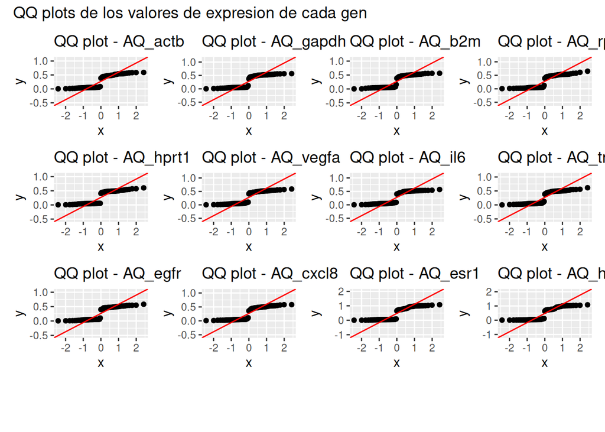

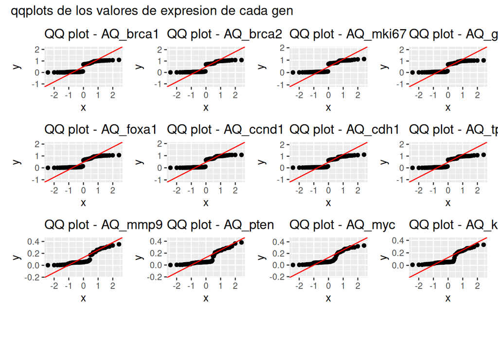

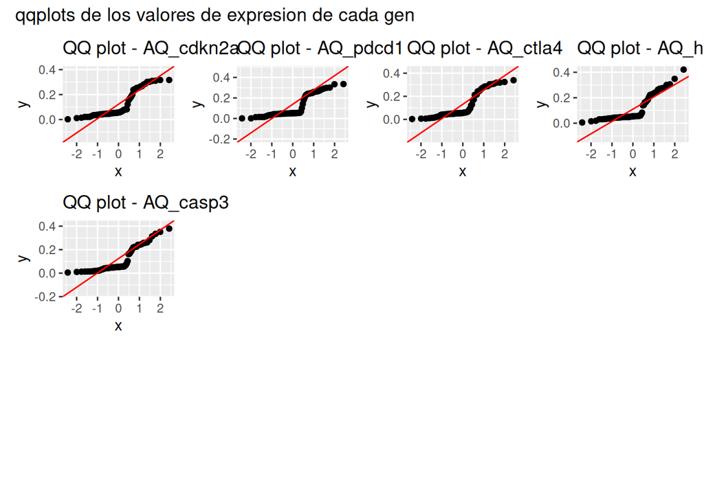

```r
# Gráfico combinado de los qqplots variables de 1-12
combined_qqplots_1 <- (qqplots[[1]] + qqplots[[2]] + qqplots[[3]] + qqplots[[4]] + qqplots[[5]] + qqplots[[6]] + qqplots[[7]] + qqplots[[8]] + qqplots[[9]] + qqplots[[10]] + qqplots[[11]] + qqplots[[12]]) +
  plot_layout(ncol = 4, nrow = 4) +
  plot_annotation(
    title = "QQ plots de los valores de expresion de cada gen",
    theme = theme_minimal()
  )

# Gráfico combinado de los qqplots variables de 13-25
combined_qqplots_2 <- (qqplots[[13]] + qqplots[[14]] + qqplots[[15]] + qqplots[[16]] + qqplots[[17]] + qqplots[[18]] + qqplots[[19]] + qqplots[[20]] + qqplots[[21]] + qqplots[[22]] + qqplots[[23]] + qqplots[[24]]) +
  plot_layout(ncol = 4, nrow = 4) +
  plot_annotation(
    title = "qqplots de los valores de expresion de cada gen",
    theme = theme_minimal()
  )

# Gráfico combinado de los qqplots variables de 26-30
combined_qqplots_3 <- (qqplots[[26]] + qqplots[[27]] + qqplots[[28]] + qqplots[[29]] + qqplots[[30]]) +
  plot_layout(ncol = 4, nrow = 4) +
  plot_annotation(
    title = "qqplots de los valores de expresion de cada gen",
    theme = theme_minimal()
  )
combined_qqplots_1;combined_qqplots_2;combined_qqplots_3
```

C/Contraste de hipótesis para reconfirmar normalidad de la expresión de los genes.

```r
tabla_modelo1 <- data.frame(
  Variable = AQ_names,
  Test_utilizado = character(length(AQ_names)),
  Valor_p = numeric(length(AQ_names)),
  Interpretación = character(length(AQ_names)),
  stringsAsFactors = FALSE
)

for (i in seq_along(AQ_names)) {
  gen <- AQ_names[i]
  x <- df_AQ[[gen]]
  x <- x[!is.na(x)] # Eliminamos los posibles NA puesto que los test de normalidad no aceptan NA

  # Elegir test según N
  if (length(x) > 50) {
    p <- ad.test(x)$p.value
    test_name <- "Anderson-Darling"
  } else {
    p <- shapiro.test(x)$p.value
    test_name <- "Shapiro-Wilk"
  }

  tabla_modelo1$Test_utilizado[i] <- test_name
  tabla_modelo1$Valor_p[i] <- p
  tabla_modelo1$Interpretación[i] <- ifelse(p > 0.05,
    "Compatible con normalidad",
    "No normal"
  )
}

tabla_modelo1
```

```r
# Formatear con gt

tabla_modelo1_gt <- tabla_modelo1 %>%
  gt() %>%
  tab_header(
    title = "Tabla modelo 1 - Prueba de normalidad de los genes"
  ) %>%
  fmt_number(
    columns = everything(),
    decimals = 2
  ) %>%
  tab_style(
    style = cell_text(weight = "bold"),
    locations = cells_column_labels(everything())
  )

tabla_modelo1_gt
```

Tabla modelo 1 - Prueba de normalidad de los genes

| Variable | Test_utilizado | Valor_p | Interpretación |
| --- | --- | --- | --- |
| AQ_actb | Anderson-Darling | 0.00 | No normal |
| AQ_gapdh | Anderson-Darling | 0.00 | No normal |
| AQ_b2m | Anderson-Darling | 0.00 | No normal |
| AQ_rpl13a | Anderson-Darling | 0.00 | No normal |
| AQ_hprt1 | Anderson-Darling | 0.00 | No normal |
| AQ_vegfa | Anderson-Darling | 0.00 | No normal |
| AQ_il6 | Anderson-Darling | 0.00 | No normal |
| AQ_tnf | Anderson-Darling | 0.00 | No normal |
| AQ_egfr | Anderson-Darling | 0.00 | No normal |
| AQ_cxcl8 | Anderson-Darling | 0.00 | No normal |
| AQ_esr1 | Anderson-Darling | 0.00 | No normal |
| AQ_her2 | Anderson-Darling | 0.00 | No normal |
| AQ_brca1 | Anderson-Darling | 0.00 | No normal |
| AQ_brca2 | Anderson-Darling | 0.00 | No normal |
| AQ_mki67 | Anderson-Darling | 0.00 | No normal |
| AQ_gata3 | Anderson-Darling | 0.00 | No normal |
| AQ_foxa1 | Anderson-Darling | 0.00 | No normal |
| AQ_ccnd1 | Anderson-Darling | 0.00 | No normal |
| AQ_cdh1 | Anderson-Darling | 0.00 | No normal |
| AQ_tp53 | Anderson-Darling | 0.00 | No normal |
| AQ_mmp9 | Anderson-Darling | 0.00 | No normal |
| AQ_pten | Anderson-Darling | 0.00 | No normal |
| AQ_myc | Anderson-Darling | 0.00 | No normal |
| AQ_kras | Anderson-Darling | 0.00 | No normal |
| AQ_akt1 | Anderson-Darling | 0.00 | No normal |
| AQ_cdkn2a | Anderson-Darling | 0.00 | No normal |
| AQ_pdcd1 | Anderson-Darling | 0.00 | No normal |
| AQ_ctla4 | Anderson-Darling | 0.00 | No normal |
| AQ_hlaa | Anderson-Darling | 0.00 | No normal |
| AQ_casp3 | Anderson-Darling | 0.00 | No normal |

**Interpretación de resultados de la Tabla 1**

La Tabla 1 resume los resultados de la evaluación de normalidad de la expresión de 30 genes mediante la prueba de Anderson-Darling. Todos los genes presentan un valor p de 0.00, lo que indica que se rechaza la hipótesis nula de normalidad en todos los supuestos. Esto implica que, de forma generalizada en el set de genes estudiado, las distribuciones de expresión génica no se ajustan a un patrón de normalidad, lo cual afecta a la selección de métodos estadísticos a seleccionar para análisis posteriores. Este resultado coincide con lo observado previamente en los histogramas y, más importante, en los QQplots, donde los datos no se ajustaban a la línea esperada en caso de normalidad.

En este contexto, el uso de técnicas paramétricas no sería adecuado, por lo que se sugiere considerar métodos no paramétricos para cumplir los supuestos requeridos. La falta de normalidad se observa tanto en genes de referencia, como ACTB y GAPDH, cuya expresión es generalmente constante; como en genes funcionalmente relevantes, incluyendo TP53, VEGFA y MYC, involucrados en la proliferación celular, metabolismo y cáncer.

Por tanto, los resultados destacan la necesidad de adaptar los análisis a la distribución real de los datos para garantizar conclusiones correctas en el estudio de la expresión génica.

**PARTE 2A** - En función del tratamiento (1er nivel) y de la extensión tumoral (2º nivel), crea una tabla descriptiva (tabla modelo 2) únicamente con las variables de genes.

```r
normalidad <- sapply(AQ_names, function(g) {
  x <- datos[[g]]
  x <- x[!is.na(x)]
  if (length(x) > 50) {
    p <- ad.test(x)$p.value
  } else {
    p <- shapiro.test(x)$p.value
  }
  return(p >= 0.05) # TRUE = normal
})

stat_list <- lapply(normalidad, function(is_normal) {
  if (is_normal) {
    "{mean} ({sd})"
  } else {
    "{median} ({p25}–{p75})"
  }
})
names(stat_list) <- AQ_names

tabla_modelo2 <- datos %>%
  select(tratamiento, extension, all_of(AQ_names)) %>%
  tbl_strata(
    strata = tratamiento,
    .tbl_fun = ~ .x %>%
      tbl_summary(
        by = extension,
        statistic = stat_list,
        digits = all_continuous() ~ 1
      ) %>%
      add_p(
        test = all_continuous() ~ "wilcox.test",
        pvalue_fun = ~ style_pvalue(.x, digits = 3)
      )
  )%>%
 modify_caption("**Tabla modelo 2 - Expresión génica según extensión de enfermedad, estratificado por tratamiento**")

tabla_modelo2
```

**Tabla modelo 2 - Expresión génica según extensión de enfermedad, estratificado por tratamiento**

| **Characteristic** | **farmaco** **localizado** N = 16<sup>1</sup> | **farmaco** **metastasico** N = 16<sup>1</sup> | **farmaco** **p-value**<sup>2</sup> | **placebo** **localizado** N = 16<sup>1</sup> | **placebo** **metastasico** N = 17<sup>1</sup> | **placebo** **p-value**<sup>2</sup> |
| --- | --- | --- | --- | --- | --- | --- |
| AQ_actb | 0.1 (0.0–0.1) | 0.5 (0.5–0.5) | <0.001 | 0.0 (0.0–0.1) | 0.5 (0.5–0.5) | <0.001 |
| AQ_gapdh | 0.0 (0.0–0.0) | 0.5 (0.5–0.5) | <0.001 | 0.1 (0.0–0.1) | 0.5 (0.5–0.5) | <0.001 |
| AQ_b2m | 0.1 (0.0–0.1) | 0.5 (0.5–0.5) | <0.001 | 0.1 (0.0–0.1) | 0.5 (0.5–0.5) | <0.001 |
| AQ_rpl13a | 0.0 (0.0–0.1) | 0.5 (0.5–0.5) | <0.001 | 0.0 (0.0–0.1) | 0.5 (0.5–0.5) | <0.001 |
| AQ_hprt1 | 0.0 (0.0–0.1) | 0.5 (0.5–0.5) | <0.001 | 0.0 (0.0–0.1) | 0.5 (0.5–0.5) | <0.001 |
| AQ_vegfa | 0.0 (0.0–0.1) | 0.5 (0.5–0.5) | <0.001 | 0.0 (0.0–0.1) | 0.5 (0.5–0.5) | <0.001 |
| AQ_il6 | 0.0 (0.0–0.1) | 0.5 (0.5–0.5) | <0.001 | 0.0 (0.0–0.1) | 0.5 (0.5–0.5) | <0.001 |
| AQ_tnf | 0.0 (0.0–0.1) | 0.5 (0.5–0.5) | <0.001 | 0.0 (0.0–0.1) | 0.5 (0.5–0.5) | <0.001 |
| AQ_egfr | 0.0 (0.0–0.1) | 0.5 (0.5–0.5) | <0.001 | 0.0 (0.0–0.1) | 0.5 (0.5–0.5) | <0.001 |
| AQ_cxcl8 | 0.0 (0.0–0.1) | 0.5 (0.5–0.5) | <0.001 | 0.0 (0.0–0.1) | 0.5 (0.5–0.5) | <0.001 |
| AQ_esr1 | 0.0 (0.0–0.1) | 0.0 (0.0–0.1) | 0.985 | 0.8 (0.7–0.8) | 1.0 (1.0–1.0) | <0.001 |
| AQ_her2 | 0.0 (0.0–0.0) | 0.0 (0.0–0.1) | 0.515 | 0.7 (0.7–0.8) | 1.0 (1.0–1.0) | <0.001 |
| AQ_brca1 | 0.0 (0.0–0.1) | 0.0 (0.0–0.0) | 0.897 | 0.8 (0.7–0.8) | 1.0 (1.0–1.0) | <0.001 |
| AQ_brca2 | 0.0 (0.0–0.1) | 0.1 (0.0–0.1) | 0.073 | 0.7 (0.7–0.8) | 1.0 (1.0–1.0) | <0.001 |
| AQ_mki67 | 0.0 (0.0–0.1) | 0.0 (0.0–0.1) | 0.809 | 0.8 (0.7–0.8) | 1.0 (1.0–1.0) | <0.001 |
| AQ_gata3 | 0.1 (0.0–0.1) | 0.0 (0.0–0.1) | 0.039 | 0.8 (0.7–0.8) | 1.0 (1.0–1.0) | <0.001 |
| AQ_foxa1 | 0.0 (0.0–0.0) | 0.1 (0.0–0.1) | 0.032 | 0.7 (0.7–0.8) | 1.0 (1.0–1.0) | <0.001 |
| AQ_ccnd1 | 0.0 (0.0–0.1) | 0.0 (0.0–0.0) | 0.539 | 0.7 (0.7–0.8) | 1.0 (1.0–1.0) | <0.001 |
| AQ_cdh1 | 0.0 (0.0–0.1) | 0.0 (0.0–0.1) | 0.539 | 0.7 (0.7–0.8) | 1.0 (1.0–1.1) | <0.001 |
| AQ_tp53 | 0.0 (0.0–0.1) | 0.0 (0.0–0.1) | 0.468 | 0.7 (0.7–0.8) | 1.0 (1.0–1.0) | <0.001 |
| AQ_mmp9 | 0.1 (0.0–0.2) | 0.0 (0.0–0.1) | 0.305 | 0.1 (0.0–0.3) | 0.1 (0.0–0.2) | 0.631 |
| AQ_pten | 0.1 (0.0–0.2) | 0.0 (0.0–0.1) | 0.985 | 0.1 (0.0–0.2) | 0.0 (0.0–0.1) | 0.110 |
| AQ_myc | 0.1 (0.0–0.1) | 0.0 (0.0–0.1) | 0.809 | 0.1 (0.1–0.2) | 0.1 (0.0–0.2) | 0.345 |
| AQ_kras | 0.1 (0.0–0.2) | 0.1 (0.0–0.2) | 0.564 | 0.1 (0.0–0.3) | 0.1 (0.0–0.2) | 0.309 |
| AQ_akt1 | 0.1 (0.0–0.2) | 0.1 (0.0–0.1) | 0.867 | 0.1 (0.0–0.3) | 0.1 (0.0–0.1) | 0.245 |
| AQ_cdkn2a | 0.1 (0.0–0.2) | 0.1 (0.0–0.2) | 0.381 | 0.1 (0.0–0.3) | 0.1 (0.0–0.2) | 0.179 |
| AQ_pdcd1 | 0.1 (0.0–0.2) | 0.1 (0.0–0.1) | 0.696 | 0.1 (0.0–0.2) | 0.1 (0.0–0.2) | 0.873 |
| AQ_ctla4 | 0.1 (0.0–0.2) | 0.1 (0.0–0.1) | 0.752 | 0.1 (0.0–0.3) | 0.1 (0.0–0.2) | 0.382 |
| AQ_hlaa | 0.1 (0.0–0.2) | 0.1 (0.0–0.1) | 0.616 | 0.1 (0.0–0.2) | 0.0 (0.0–0.2) | 0.168 |
| AQ_casp3 | 0.0 (0.0–0.2) | 0.1 (0.0–0.2) | 0.287 | 0.1 (0.0–0.2) | 0.1 (0.0–0.2) | 0.345 |

<sup>1</sup> Median (Q1–Q3)  
<sup>2</sup> Wilcoxon rank sum exact test

**Interpretación de los resultados de la Tabla 2**

En la tabla 2 vemos la comparación de la expresión génica entre tumores localizados y metastásicos, estratificada por tratamiento (grupo fármaco versus grupo placebo). Para ellos se emplea el método estadístico del test de Wilcoxon, para la comparación de medianas de dos grupos independientes de datos no paramétricos.

En el grupo tratado con el fármaco, se observan diferencias estadísticamente significativas entre los tumores localizados y los metastásicos para varios genes, como GATA3 y FOXA1 relacionados con proliferación y diferenciación tumoral. Esto puede sugierir cambios en los patrones de expresión génica asociados al estado metastásico. En cambio, genes clave implicados en oncogénesis como TP53, BRCA1/2 o MYC no muestran diferencias significativas en este grupo. En el grupo placebo, la mayoría de los genes presentan diferencias significativas entre los estados tumorales, siendo la expresión más elevada en los casos de tumores metastásicos. Esto indica una asociación entre la progresión tumoral y la sobreexpresión génica en ausencia de tratamiento.

Por tanto, los resultados sugieren un posible efecto del fármaco en la disminución de la magnitud de la sobreexpresión génica en tumores metastásicos.

**PARTE 2B** - En función de la edad en 2 categorías según la mediana (categoría 1: edad <percentil 50 de edad; categoría 2: edad >=percentil 50 de edad), crea una tabla descriptiva (tabla modelo 3) únicamente con las variables de genes.

```r
p50_edad <- quantile(datos$edad, probs = 0.50, na.rm = TRUE)

datos <- datos %>%
  mutate(
    edad_cat = cut(
      edad,
      breaks = c(-Inf, p50_edad, Inf),
      labels = c("Edad_cat < percentil 50", "Edad_cat ≥ percentil 50"),
      right = FALSE
    )
  )

tabla_modelo3 <- datos %>%
  select(edad_cat, all_of(AQ_names)) %>%
  tbl_summary(
    by = edad_cat,
    statistic = stat_list,
    digits = all_continuous() ~ 1
  ) %>%
  add_p(
    test = all_continuous() ~ "wilcox.test",
    pvalue_fun = ~ style_pvalue(.x, digits = 3)
  ) %>%

  modify_caption("**Tabla modelo 3 - Comparación de expresión génica según edad**")

tabla_modelo3
```

**Tabla modelo 3 - Comparación de expresión génica según edad**

| **Characteristic** | **Edad_cat < percentil 50** N = 32<sup>1</sup> | **Edad_cat ≥ percentil 50** N = 33<sup>1</sup> | **p-value**<sup>2</sup> |
| --- | --- | --- | --- |
| AQ_actb | 0.4 (0.1–0.5) | 0.1 (0.0–0.5) | 0.193 |
| AQ_gapdh | 0.4 (0.1–0.5) | 0.1 (0.0–0.5) | 0.681 |
| AQ_b2m | 0.4 (0.0–0.5) | 0.1 (0.1–0.5) | 0.749 |
| AQ_rpl13a | 0.4 (0.0–0.5) | 0.1 (0.0–0.5) | 0.789 |
| AQ_hprt1 | 0.4 (0.0–0.5) | 0.1 (0.1–0.5) | 0.901 |
| AQ_vegfa | 0.5 (0.1–0.5) | 0.1 (0.0–0.5) | 0.084 |
| AQ_il6 | 0.4 (0.0–0.5) | 0.1 (0.0–0.5) | 0.318 |
| AQ_tnf | 0.4 (0.1–0.5) | 0.1 (0.0–0.5) | 0.087 |
| AQ_egfr | 0.4 (0.0–0.5) | 0.1 (0.0–0.5) | 0.407 |
| AQ_cxcl8 | 0.4 (0.0–0.5) | 0.1 (0.0–0.5) | 0.672 |
| AQ_esr1 | 0.7 (0.1–1.0) | 0.1 (0.0–0.8) | 0.152 |
| AQ_her2 | 0.7 (0.0–1.0) | 0.1 (0.0–0.8) | 0.415 |
| AQ_brca1 | 0.7 (0.0–1.0) | 0.1 (0.0–0.8) | 0.189 |
| AQ_brca2 | 0.7 (0.0–1.0) | 0.1 (0.0–0.8) | 0.253 |
| AQ_mki67 | 0.7 (0.0–1.0) | 0.1 (0.0–0.8) | 0.493 |
| AQ_gata3 | 0.8 (0.1–1.0) | 0.1 (0.0–0.8) | 0.097 |
| AQ_foxa1 | 0.7 (0.0–1.0) | 0.1 (0.0–0.8) | 0.779 |
| AQ_ccnd1 | 0.7 (0.0–1.0) | 0.1 (0.0–0.7) | 0.502 |
| AQ_cdh1 | 0.7 (0.0–1.0) | 0.1 (0.0–0.8) | 0.247 |
| AQ_tp53 | 0.7 (0.0–1.0) | 0.1 (0.1–0.8) | 0.422 |
| AQ_mmp9 | 0.1 (0.0–0.2) | 0.0 (0.0–0.1) | 0.222 |
| AQ_pten | 0.1 (0.0–0.2) | 0.0 (0.0–0.1) | 0.019 |
| AQ_myc | 0.1 (0.0–0.2) | 0.1 (0.0–0.1) | 0.059 |
| AQ_kras | 0.1 (0.0–0.2) | 0.1 (0.0–0.1) | 0.212 |
| AQ_akt1 | 0.1 (0.0–0.2) | 0.1 (0.0–0.1) | 0.415 |
| AQ_cdkn2a | 0.1 (0.0–0.2) | 0.1 (0.0–0.1) | 0.137 |
| AQ_pdcd1 | 0.1 (0.0–0.2) | 0.1 (0.0–0.1) | 0.461 |
| AQ_ctla4 | 0.1 (0.1–0.2) | 0.1 (0.0–0.1) | 0.171 |
| AQ_hlaa | 0.1 (0.0–0.2) | 0.0 (0.0–0.1) | 0.094 |
| AQ_casp3 | 0.1 (0.1–0.2) | 0.0 (0.0–0.1) | 0.001 |

<sup>1</sup> Median (Q1–Q3)  
<sup>2</sup> Wilcoxon rank sum exact test

**Interpretación de los resultados de la Tabla 3**

La tabla 3 compara la expresión génica entre los dos grupos de edad. Para el análisis, se utiliza en el método estadístico del test de Wilcoxon, para la comparación de medianas de dos grupos independientes de datos no paramétricos.

La mayoría de genes evaluados (como actb, gapdh o b2m) son genes relacionados con proliferación y regulación celular que no presentan diferencias significativas entre grupos (p>0.05). Sin embargo, destacan dos únicos genes con significación estadística, PTEN y CASP3. Estos dos genes presentan menor expresión en el grupo ≥P50.

PTEN es un supresor tumoral clave y CASP3 participa en el proceso de apoptosis celular. Por tanto, su menor expresión en el grupo ≥P50 podría indicar mayor potencial proliferativo así como la resistencia a la muerte celular. Esto tiene sentido biológico puesto que el cáncer es más agresivo en pacientes de mayor edad, situados en el grupo ≥P50.